# Research Design and Analysis

Prof Randi Garcia  
September 02, 2021

Welcome to **SDS 290**!

### Introductions

Who am I?

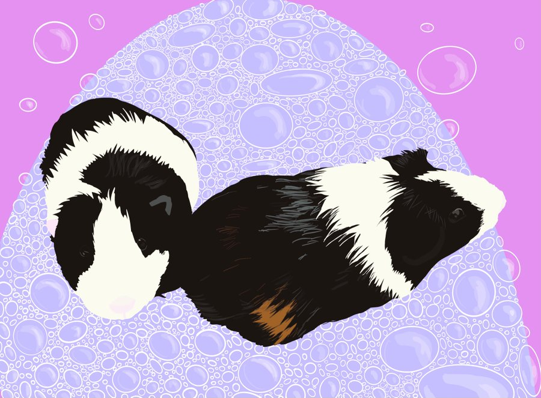

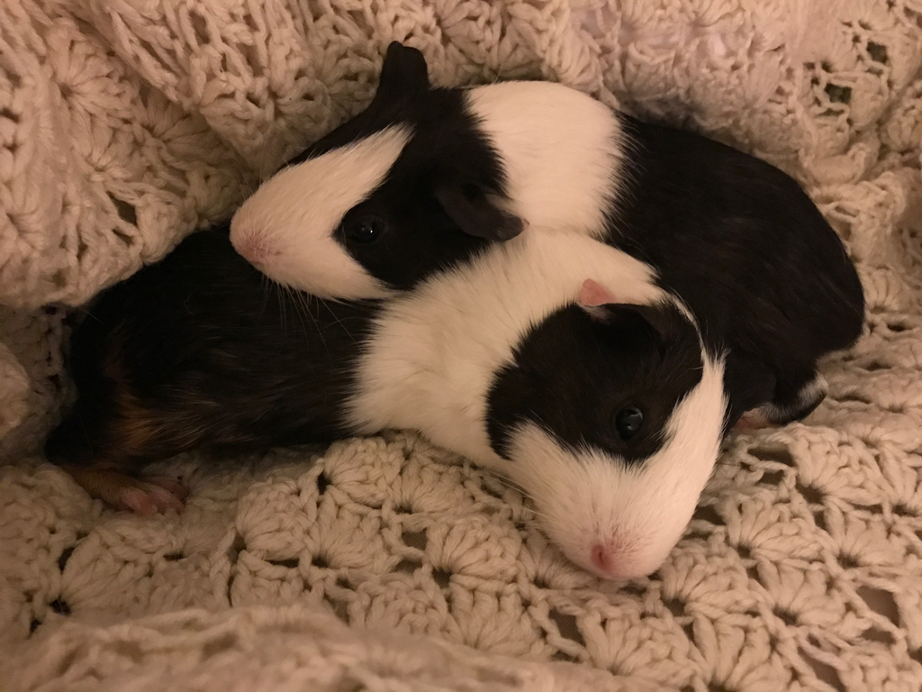

### #Goals

Now it is your turn. But first, let's do a 2-minute free write

### Introductions

In groups of three introduce yourselves…

- Name
- Pronouns
- One goal for this course
- Favorite animal

### Introduction to SDS/MTH 290

- Course website at https://bit.ly/sds290fall2021
- Syllabus

### Our First Experiment

Get in breakout groups of ~8 we will discuss.

As you participate in the experiment remember:

- what you saw
- what you did
- the order in which it happened.

To participate, find the experiment link in the course schedule!!

### Our First Experiment

In your groups:

- Take turns describing what you saw/did.
- Your objective, as a group, is to describe the FULL experimental design.

Discussion questions:

- What were all of the possibilities? How do you think that was determined?
- Which conditions were distributed *across* people, and which *within* people?
- What do you think are the possible research questions answered by this study?